# 时序第6次作业

苏锦华 2017201620

# 4.2

# 4.5

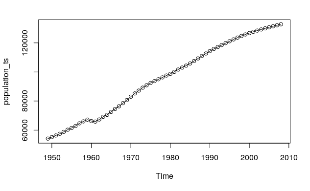

```r
table =read.table('../习题数据/习题4.5数据.txt',fill =T)
population = c()
for(i in 1:8){
  for(j in 1:8){
    if (i != 8 || j <= 4){
      population = c(population,table[i,j])
    }
  }
}
population_ts = ts(population,start=1949)
plot(population_ts,type="o")
```

做出图后发现，图像基本呈现线性，可以用线性模型拟合，但是结合国情可知，从2000年以来我国人口增速逐渐放缓，所以还是使用指数平滑来拟合更多的近期信息,由于曲线有明显的趋势而没有明显的季节性，选用Holt两参数指数平滑。

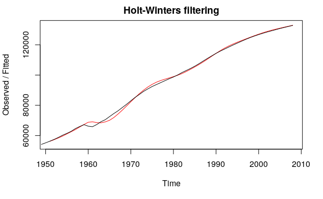

```r
library(forecast)
Holfit <- HoltWinters(population_ts,alpha=0.3,beta=0.6,gamma=F)
fore <- forecast(Holfit, h=5)
plot(Holfit)
```

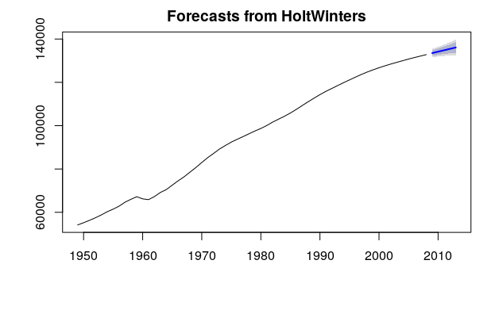

```r
plot(fore)
```

```r
Holfit
```

```
Holt-Winters exponential smoothing with trend and without seasonal component.

Call:
HoltWinters(x = population_ts, alpha = 0.3, beta = 0.6, gamma = F)

Smoothing parameters:
 alpha: 0.3
 beta : 0.6
 gamma: FALSE

Coefficients:
         [,1]
a 132866.4328
b    646.4791
```

考虑到图形中1960年左右的三年饥荒对近期预测价值不大，所以应当将平滑因子调大，使得预测更加结合近期数据，令alpha=0.3，beta=0.6，发现拟合效果比较理想，拟合的斜率比较接近近期，最后输出其预测结果。发现预测结果最终2013年预计为13.6亿，查询实际结果为135404万人，在80%置信区间以内，预测效果非常不错。

```r
fore
```

|  | Point Forecast | Lo 80 | Hi 80 | Lo 95 | Hi 95 |
| --- | --- | --- | --- | --- | --- |
| 2009 | 133512.9 | 132191.6 | 134834.2 | 131492.1 | 135533.7 |
| 2010 | 134159.4 | 132693.8 | 135625.0 | 131917.9 | 136400.9 |
| 2011 | 134805.9 | 133100.4 | 136511.3 | 132197.6 | 137414.1 |
| 2012 | 135452.3 | 133417.5 | 137487.2 | 132340.4 | 138564.3 |
| 2013 | 136098.8 | 133658.2 | 138539.5 | 132366.2 | 139831.5 |